# indivdual3

Allan Juarez

9/27/2020

```r
dat <- readxl::read_xls('./GSS.xls')
summary(dat)
```

```
##  Gss year for this respondent General happiness  Religion in which raised
##  Min.   :1972                 Length:64816       Length:64816
##  1st Qu.:1984                 Class :character   Class :character
##  Median :1996                 Mode  :character   Mode  :character
##  Mean   :1995
##  3rd Qu.:2006
##  Max.   :2018
##  NA's   :2
##  Political party affiliation Respondents sex    Rs highest degree
##  Length:64816                Length:64816       Length:64816
##  Class :character            Class :character   Class :character
##  Mode  :character            Mode  :character   Mode  :character
##
##
##
##
##  Highest year of school completed Number of children Marital status
##  Length:64816                     Length:64816       Length:64816
##  Class :character                 Class :character   Class :character
##  Mode  :character                 Mode  :character   Mode  :character
##
##
##
##
##  R self-emp or works for somebody Respondent id number
##  Length:64816                     Min.   :   1
##  Class :character                 1st Qu.: 507
##  Mode  :character                 Median :1030
##                                   Mean   :1152
##                                   3rd Qu.:1570
##                                   Max.   :4510
##                                   NA's   :2
##  Ballot used for interview
##  Length:64816
##  Class :character
##  Mode  :character
##
##
##
##
```

```r
library(dplyr)
```

```r
library(ggplot2)
library(classdata)
```

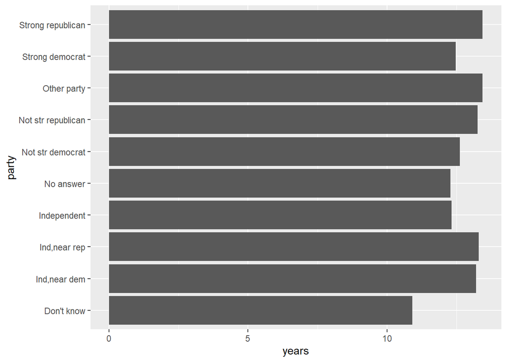

```r
education <- dat[c('Political party affiliation','Highest year of school completed')]

education <- filter(education, education$'Highest year of school completed' != 'No answer')
education <- filter(education, education$'Highest year of school completed' != "Don't know")
education$'Highest year of school completed' <- as.numeric(education$'Highest year of school completed')

education <- aggregate(education$'Highest year of school completed',list(education$'Political party affiliation'), FUN = mean)
education <- education %>% rename(party = Group.1, years = x)

ggplot(education, aes(x=party, y=years)) + geom_bar(stat = "identity")+coord_flip()
```

1. Looking at the average years of school for every party. YOu can see that there are about three types of the two parties. Strong, Not Str, INd, in every category republicans average more years of school than democrats. The lowest average of years in school tended to not know their affiliation.

```r
second <-dat

education <- dat[c('Political party affiliation','Highest year of school completed')]
education <- filter(education, education$'Highest year of school completed' != 'No answer')
education <- filter(education, education$'Highest year of school completed' != "Don't know")
education$'Highest year of school completed' <- as.numeric(education$'Highest year of school completed')
education <- aggregate(education$'Highest year of school completed',list(education$'Political party affiliation'), FUN = median)
education
```

```
##               Group.1  x
## 1          Don't know 11
## 2        Ind,near dem 13
## 3        Ind,near rep 13
## 4         Independent 12
## 5           No answer 12
## 6    Not str democrat 12
## 7  Not str republican 13
## 8         Other party 13
## 9     Strong democrat 12
## 10  Strong republican 13
```

```r
second <- filter(second, second$'Highest year of school completed' != 'No answer')
second <- filter(second, second$'Highest year of school completed' != "Don't know")

second$'Highest year of school completed' <- as.numeric(second$'Highest year of school completed')
strongRep <- filter(second,second$'Political party affiliation' == 'Strong republican' & second$'Highest year of school completed' >13)

strongDem <- filter(second,second$'Political party affiliation' == 'Strong democrat' & second$'Highest year of school completed' >12)

other <- filter(second,second$'Political party affiliation' == 'Other party' & second$'Highest year of school completed' >13)

notStrRep <- filter(second,second$'Political party affiliation' == 'Not str republican' & second$'Highest year of school completed' >13)

notStrDem <- filter(second,second$'Political party affiliation' == 'Not str democrat' & second$'Highest year of school completed' >12)

no <- filter(second,second$'Political party affiliation' == 'No answer' & second$'Highest year of school completed' >12)

independent <- filter(second,second$'Political party affiliation' == 'Independent' & second$'Highest year of school completed' >12)
inrep <- filter(second,second$'Political party affiliation' == 'Ind,near rep' & second$'Highest year of school completed' >13)

indem <- filter(second,second$'Political party affiliation' == 'Ind,near dem' & second$'Highest year of school completed' >13)

know <- filter(second,second$'Political party affiliation' == "Don't know" & second$'Highest year of school completed' >11)

betterEduacatied <- rbind(strongRep,strongDem)
betterEduacatied <- rbind(betterEduacatied,other)
betterEduacatied <- rbind(betterEduacatied,notStrRep)
betterEduacatied <- rbind(betterEduacatied,notStrDem)
betterEduacatied <- rbind(betterEduacatied,independent)
betterEduacatied <- rbind(betterEduacatied,inrep)
betterEduacatied <- rbind(betterEduacatied,indem)
betterEduacatied <- rbind(betterEduacatied,know)

betterEduacatied
```

```
## # A tibble: 27,692 x 12
##    `Gss year for t~ `General happin~ `Religion in wh~ `Political part~
##               <dbl> <chr>            <chr>            <chr>
##  1             1972 Pretty happy     Not applicable   Strong republic~
##  2             1972 Very happy       Not applicable   Strong republic~
##  3             1972 Very happy       Not applicable   Strong republic~
##  4             1972 Very happy       Not applicable   Strong republic~
##  5             1972 Pretty happy     Not applicable   Strong republic~
##  6             1972 Pretty happy     Not applicable   Strong republic~
##  7             1972 Very happy       Not applicable   Strong republic~
##  8             1972 Pretty happy     Not applicable   Strong republic~
##  9             1972 Pretty happy     Not applicable   Strong republic~
## 10             1972 Pretty happy     Not applicable   Strong republic~
## # ... with 27,682 more rows, and 8 more variables: `Respondents sex` <chr>, `Rs
## #   highest degree` <chr>, `Highest year of school completed` <dbl>, `Number of
## #   children` <chr>, `Marital status` <chr>, `R self-emp or works for
## #   somebody` <chr>, `Respondent id number` <dbl>, `Ballot used for
## #   interview` <chr>
```

2. the median years were used to figure out years

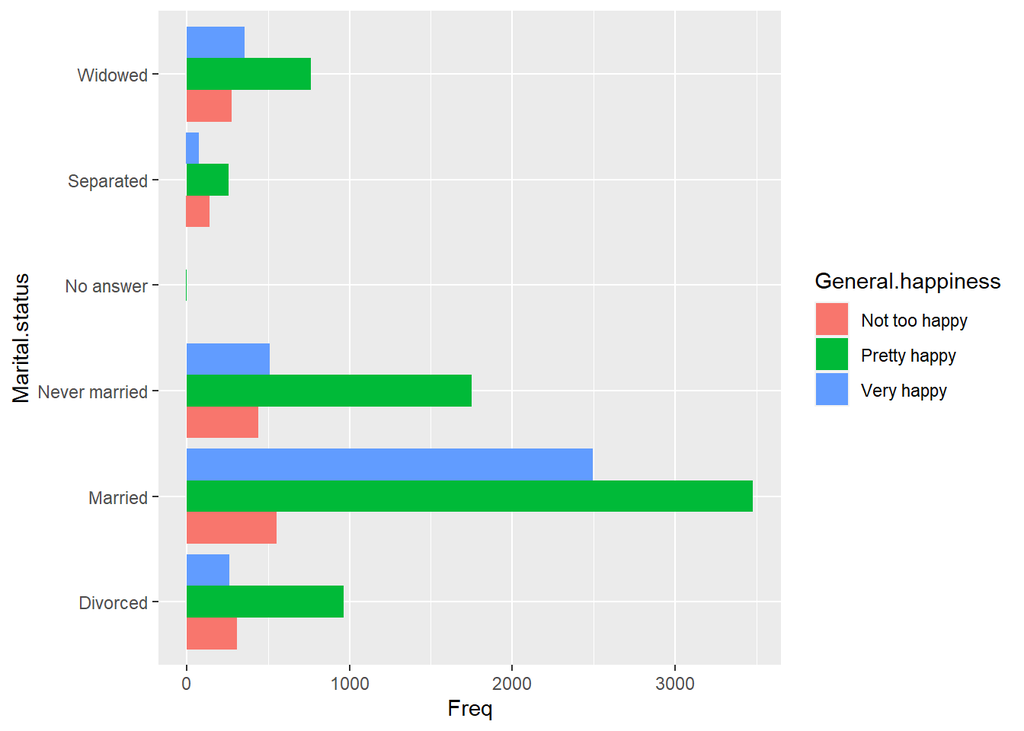

```r
marriage <- dat[c('General happiness','Marital status','Political party affiliation')]
marriage <- filter(marriage, marriage$'General happiness' == 'Very happy' | marriage$'General happiness' == 'Pretty happy' | marriage$'General happiness' == 'Not too happy')
marriage <-
marriage <- table(marriage)
marriage <- as.data.frame(marriage)

ggplot(marriage, aes(x=Marital.status, y=Freq)) + geom_bar(aes(fill = General.happiness),stat = "identity",position = "dodge")+coord_flip()
```

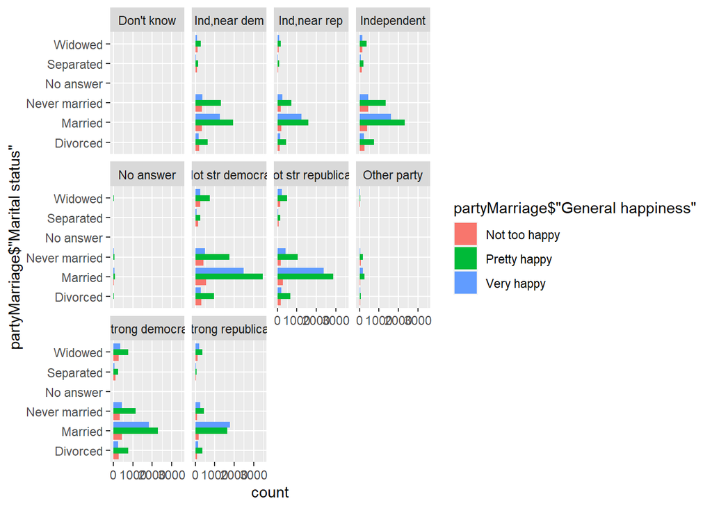

```r
partyMarriage <- dat[c('General happiness','Marital status','Political party affiliation')]
partyMarriage <- filter(partyMarriage, partyMarriage$'General happiness' == 'Very happy' | partyMarriage$'General happiness' == 'Pretty happy' | partyMarriage$'General happiness' == 'Not too happy')

partyMarriage <- filter(partyMarriage, partyMarriage$'Political party affiliation' != "Don't know" | partyMarriage$'Political party affiliation' != "No answer")

ggplot(partyMarriage, aes(partyMarriage$'Marital status', fill =partyMarriage$'General happiness' ))+ geom_bar(position = "dodge")+ facet_wrap(~partyMarriage$'Political party affiliation') +coord_flip()
```

4. Looking at this there doesnt seem to be a trend between martial status and political party they are all very simlar.

```r
happy <- dat[c('Marital status','Highest year of school completed')]

happy <- filter(happy, happy$'Highest year of school completed' != 'No answer')
happy <- filter(happy, happy$'Highest year of school completed' != "Don't know")
happy <- filter(happy, happy$'Marital status' != "No answer")
happy$'Highest year of school completed' <- as.numeric(happy$'Highest year of school completed')
happy <- aggregate(happy$'Highest year of school completed',list(happy$'Marital status'), FUN = mean)
happy <- happy %>% rename(party = Group.1, years = x)
happy
```

```
##           party    years
## 1      Divorced 13.10582
## 2       Married 12.96828
## 3 Never married 13.38954
## 4     Separated 11.85580
## 5       Widowed 11.19825
```

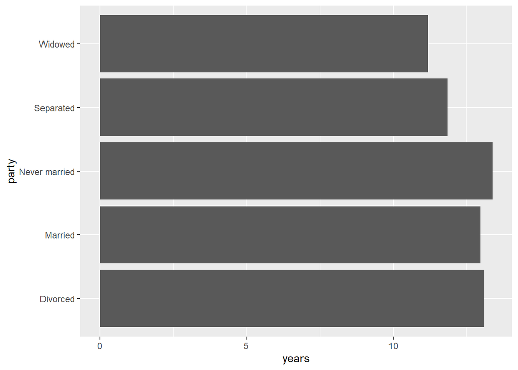

```r
ggplot(happy, aes(x=party, y=years)) + geom_bar(stat = "identity")+coord_flip()
```

5. all the statuses are pretty similar id say there is at least a visual difference on widowed and separated apart from the rest of the groups. Numerically widowed is the lowest with 11 and divorced, married and never is hovering around 13.

```r
employed <-dat[c('R self-emp or works for somebody','General happiness')]
employed <- filter(employed, employed$'General happiness' == 'Very happy' | employed$'General happiness' == 'Pretty happy' | employed$'General happiness' == 'Not too happy')
employed <- filter(employed, employed$'R self-emp or works for somebody' != 'No answer' )
employed <- filter(employed, employed$'R self-emp or works for somebody' != 'Not applicable')
 employed <- filter(employed,employed$'R self-emp or works for somebody' != "Don't know" )
employed <- table(employed)
employed <- as.data.frame(employed)
employed
```

```
##   R.self.emp.or.works.for.somebody General.happiness  Freq
## 1                    Self-employed     Not too happy   709
## 2                     Someone else     Not too happy  6344
## 3                    Self-employed      Pretty happy  3459
## 4                     Someone else      Pretty happy 28195
## 5                    Self-employed        Very happy  2292
## 6                     Someone else        Very happy 15472
```

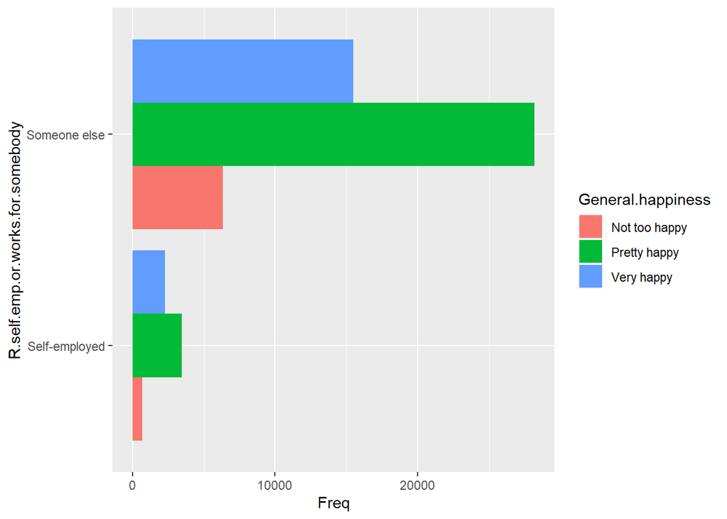

```r
ggplot(employed, aes(x=R.self.emp.or.works.for.somebody, y=Freq)) + geom_bar(aes(fill = General.happiness),stat = "identity",position = "dodge")+coord_flip()
```

### This lab was well done and investigated the questions well. Some ways to improve could have been making new names for the columns to avoid having to type out the long values for column names and use some of the tools in tidyverse to make things easier but other than that it was well put together. - Colin Willenborg